# Interest Rates and R&D - Proof of Concept

Author

David Gonzalez Chavez

# Data

The data for this comes from the OECD. It includes R&D expenditures by country (as a percentage of country GDP) and the interest rates of each country by year.

```r
OECD_RD_All <- read_csv("OECD_RD_All.csv")

OECD_RD_Inf <- read_csv("OECD_RD_InformationOnly.csv")

OECD_InterestRates <- read_csv("OECD_InterestRates.csv")

OECD_InterestRates <- OECD_InterestRates |>
  select(REF_AREA, TIME_PERIOD, OBS_VALUE) |>
  rename(year = TIME_PERIOD, country_iso = REF_AREA, interbank_rate = OBS_VALUE)

OECD_RD_Inf <- OECD_RD_Inf |>
  select(ISO, Year, Value) |>
  rename(year = Year, country_iso = ISO, information_rd_percentGDP = Value)
```

# Analysis

The following analysis tests the hypothesis that a country’s interest rate has an inverse relationship with spending on R&D within the information sector (as a percentage of GDP).

```r
infoRD_intRate <- left_join(OECD_RD_Inf, OECD_InterestRates, by = c("year", "country_iso")) |>
  drop_na()

model = lm(formula = information_rd_percentGDP ~  interbank_rate, data = infoRD_intRate)

summary(model)
```

```
Call:
lm(formula = information_rd_percentGDP ~ interbank_rate, data = infoRD_intRate)

Residuals:
     Min       1Q   Median       3Q      Max
-0.39468 -0.25014 -0.12763 -0.00143  3.08547

Coefficients:
                Estimate Std. Error t value Pr(>|t|)
(Intercept)     0.405045   0.022951  17.649   <2e-16 ***
interbank_rate -0.015128   0.007271  -2.081   0.0379 *
---
Signif. codes:  0 '***' 0.001 '**' 0.01 '*' 0.05 '.' 0.1 ' ' 1

Residual standard error: 0.4698 on 568 degrees of freedom
Multiple R-squared:  0.007564,  Adjusted R-squared:  0.005817
F-statistic: 4.329 on 1 and 568 DF,  p-value: 0.03791
```

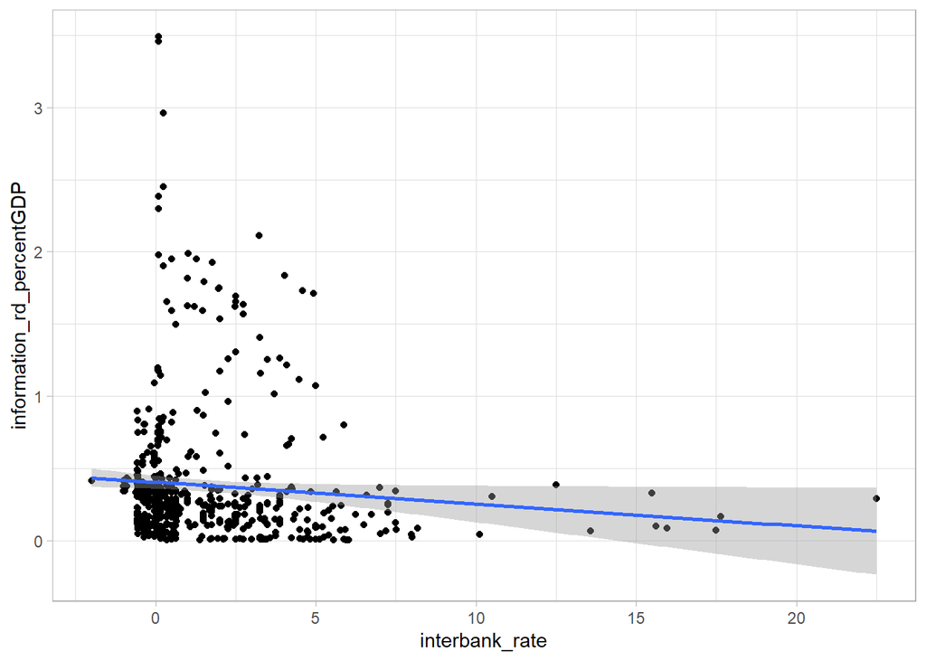

```r
ggplot(data = infoRD_intRate,
aes(x = interbank_rate, y = information_rd_percentGDP)) +
  geom_point() +
  geom_smooth(method="lm", formula = y ~ x)
```

This analysis suggests that increasing in interest rates do decrease spending on R&D. A 1-percentage point increase in interbank rates results in a 0.015% drop in R&D spending as a percent of GDP. Relative to the mean spending on R&D, this is around a 4% decrease.

This finding is consisting with the existing literature; for instance, “For every 1 percentage point rise in interest rates, Ma and Zimmermann calculate, R&D spending fell by between 1 and 3 percent and VC investment fell by about 25 percent one to three years after the hike. Similarly, within four years of an interest-rate increase, patent filings and innovation each declined by 9 percent.” per https://www.chicagobooth.edu/review/high-interest-rates-harm-innovation

The lagged impact of interest rate changes has been studied, but no connection in the literature exists between interest rates and organizational imprinting. This is the foundation for what I hope to analyze.

# Future Datasources

## US-Specific

### National Center for Science and Engineering Statistics

The National Center for Science and Engineering Statistics has lots of datasets with survey data about company R&D spend, from businesses with only 1 to 9 employees to large businesses.

This includes the Business Enterprise Research and Development Survey (BERD) and the Annual Business Survey (ABS)

https://ncses.nsf.gov/browse-library?dataCollection=Business%20and%20Industry%20R%26D

## Japan-Specific

### Nikkei Dataset

Nikkei contains several datasets that coul dbe useful.

https://nkbb.nikkei.co.jp/en/dataset/corporate-fundamentals/#corporate-financial-statements

## Multi-National

### Bloomberg

Bloomberg has lots of datasets containing comprehensive financial information for companies. One dataset, the Fundamentals database, includes 85k public, private, delisted, active, and inactive companies across more than 115 countries. This would be valuable for getting information like R&D spending or more granular data like spending on administrative roles.

https://data.bloomberglp.com/professional/sites/10/189913_CDS_REF_Fundamentals_SFCT_DIG.pdf

### OECD

The OECD has great data on yearly interest rates (short-term, long-term, and interbank) by country.

https://www.oecd.org/en/data/datasets.html